# BACS HW (Week 6)

108020024

Helped by 108020033

due on 03/26 (Sun)

### Question 1) The Verizon dataset this week is provided as a “wide” data frame. Let’s practice reshaping it to a “long” data frame. You may use either shape (wide or long) for your analyses in later questions.

### a) Pick a reshaping package (we discussed two in class) – research them online and tell us why you picked it over others (provide any helpful links that supported your decision).

Both reshape2 and **tidyr** did similar jobs, however **tidyr** is a package specifically designed for data tidying, and most importantly **tidyr** is a core package to Tidyverse series, a collection of R packages that share common principles and are designed to work together seamlessly, this makes **tidyr** more competitive against reshape2, so I choose **tidyr** as the reshaping package in this homework.

### b) Show the code to reshape the verizon_wide.csv sample

```r
verizon_wide <- read.csv("verizon_wide.csv")
#install.packages("tidyr")
library(tidyr)
verizon_long <- gather(verizon_wide, na.rm = TRUE,key = "host",value = "load_time")
```

### c) Show us the “head” and “tail” of the data to show that the reshaping worked

```r
head(verizon_long)
```

|  | host | load_time |
| --- | --- | --- |
| 1 | ILEC | 17.50 |
| 2 | ILEC | 2.40 |
| 3 | ILEC | 0.00 |
| 4 | ILEC | 0.65 |
| 5 | ILEC | 22.23 |
| 6 | ILEC | 1.20 |

```r
tail(verizon_long)
```

|  | host | load_time |
| --- | --- | --- |
| 1682 | CLEC | 24.20 |
| 1683 | CLEC | 22.13 |
| 1684 | CLEC | 18.57 |
| 1685 | CLEC | 20.00 |
| 1686 | CLEC | 14.13 |
| 1687 | CLEC | 5.80 |

### d) Visualize Verizon’s response times for ILEC vs. CLEC customers

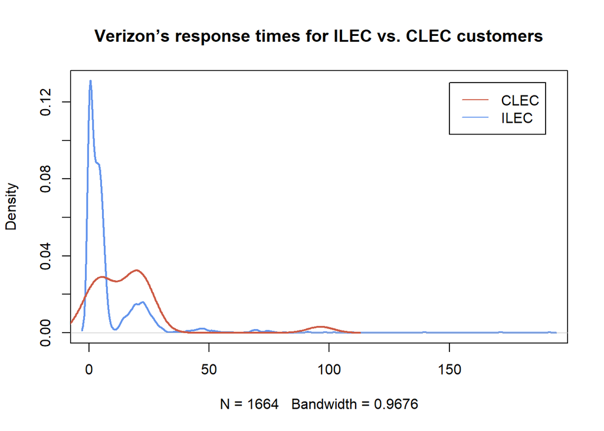

```r
hosts <- split(x = verizon_long$load_time, f = verizon_long$host)
plot(density(hosts$ILEC), col="cornflowerblue", lwd=2, xlim=c(0, max(verizon_long$load_time)),main = "Verizon’s response times for ILEC vs. CLEC customers")
lines(density(hosts$CLEC), col="coral3", lwd=2)
legend(150, 0.13, lty=1, c("CLEC", "ILEC"), col=c("coral3", "cornflowerblue"))
```

### Question 2) Let’s test if the mean of response times for CLEC customers is greater than for ILEC customers

### a) State the appropriate null and alternative hypotheses (one-tailed)

$H_0$ : The mean of response times for CLEC customers $\leq$ the mean of response times for ILEC customers

$H_1$ : The mean of response times for CLEC customers $>$ the mean of response times for ILEC customers

### b) Use the appropriate form of the t.test() function to test the difference between the mean of ILEC versus CLEC response times at 1% significance. For each of the following tests, show us the results and tell us whether you would reject the null hypothesis.

```
    i) Conduct the test assuming variances of the two populations are equal
```

```r
t.test(hosts$ILEC, hosts$CLEC ,alternative="less",conf.level = 0.99, var.equal = TRUE )
```

```
##
##  Two Sample t-test
##
## data:  hosts$ILEC and hosts$CLEC
## t = -2.6125, df = 1685, p-value = 0.004534
## alternative hypothesis: true difference in means is less than 0
## 99 percent confidence interval:
##        -Inf -0.8801387
## sample estimates:
## mean of x mean of y
##  8.411611 16.509130
```

The overall p-value = 0.004534 < 0.01, reject $H_0$, accept $H_1$ at 99% confidence.

```
    ii) Conduct the test assuming variances of the two populations are not equal
```

```r
t.test(hosts$ILEC, hosts$CLEC ,alternative="less",conf.level = 0.99, var.equal = FALSE )
```

```
##
##  Welch Two Sample t-test
##
## data:  hosts$ILEC and hosts$CLEC
## t = -1.9834, df = 22.346, p-value = 0.02987
## alternative hypothesis: true difference in means is less than 0
## 99 percent confidence interval:
##      -Inf 2.130858
## sample estimates:
## mean of x mean of y
##  8.411611 16.509130
```

The overall p-value = 0.02987 > 0.01, cannot reject $H_0$ at 99% confidence.

### c) Use a permutation test to compare the means of ILEC vs. CLEC response times

```
    i) Visualize the distribution of permuted differences, and indicate the observed difference as well.
```

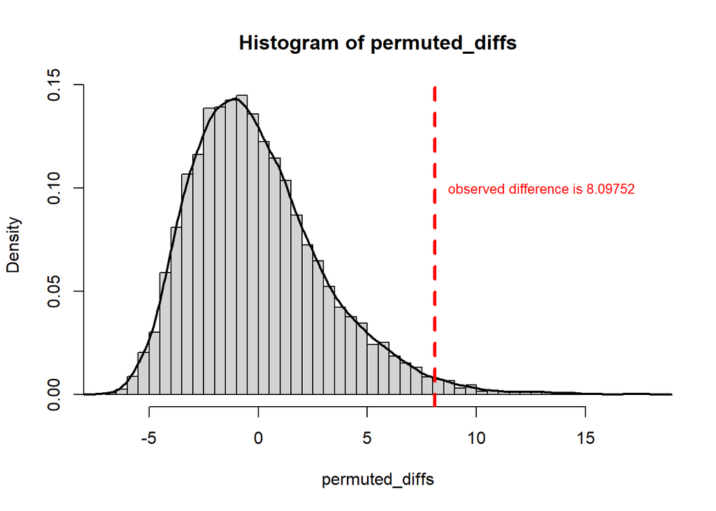

```r
observed_diff <- mean(hosts$CLEC) - mean(hosts$ILEC)

permute_diff <- function(values, groups) {
permuted <- sample(values, replace = FALSE)
grouped <- split(permuted, groups)
permuted_diff <- mean(grouped$CLEC) - mean(grouped$ILEC)
}
nperms <- 10000

permuted_diffs <- replicate(nperms, permute_diff(verizon_long$load_time, verizon_long$host))
hist(permuted_diffs, breaks = "fd", probability = TRUE)
lines(density(permuted_diffs), lwd=2)
abline(v = observed_diff, col="red", lwd=3, lty=2)
text(13,0.1,labels="observed difference is 8.09752", cex=0.8, col="red")
```

The observed difference is 8.09752.

```
    ii) What are the one-tailed and two-tailed p-values of the permutation test?
```

```r
p_1tailed <- sum(permuted_diffs > observed_diff) / nperms
p_2tailed <- sum(abs(permuted_diffs) > observed_diff) / nperms
```

The one-tailed p-value is 0.0172.

The two-tailed p-value is 0.0172.

```
    iii) Would you reject the null hypothesis at 1% significance in a one-tailed test?
```

The overall p-value = 0.0172 > 0.01, cannot reject $H_0$ at 1% significance.

### Question 3) Let’s use the Wilcoxon test to see if the response times for CLEC are different than ILEC.

### a) Compute the W statistic comparing the values. You may use either the permutation approach (try the functional form) or the rank sum approach.

```r
gt_eq <- function(a, b) {
ifelse(a > b, 1, 0) + ifelse(a == b, 0.5, 0)
}
W <- sum(outer(hosts$CLEC, hosts$ILEC, FUN = gt_eq))
```

The W statistic is 26820.

### b) Compute the one-tailed p-value for W.

```r
n1 <- length(hosts$CLEC)
n2 <- length(hosts$ILEC)

wilcox_p_1tail <- 1 - pwilcox(W, n1, n2)
```

The one-tailed p-value for W is 3.6883415^{-4}.

### c) Run the Wilcoxon Test again using the wilcox.test() function in R – make sure you get the same W as part [a]. Show the results.

```r
wilcox.test(hosts$CLEC, hosts$ILEC, alternative = "greater")
```

```
##
##  Wilcoxon rank sum test with continuity correction
##
## data:  hosts$CLEC and hosts$ILEC
## W = 26820, p-value = 0.0004565
## alternative hypothesis: true location shift is greater than 0
```

### d) At 1% significance, and one-tailed, would you reject the null hypothesis that the values of CLEC and ILEC are similar?

The overall p-value = 0.0004565 < 0.01, reject the null hypothesis that the values of CLEC and ILEC are similar at 1% significance.

### Question 4) One of the assumptions of some classical statistical tests is that our population data should be roughly normal. Let’s explore one way of visualizing whether a sample of data is normally distributed.

### a) Follow the following steps to create a function to see how a distribution of values compares to a perfectly normal distribution. The ellipses (…) in the steps below indicate where you should write your own code.

```
    i) Create a sequence of probability numbers from 0 to 1, with ~1000 probabilities in between
    ii) Calculate ~1000 quantiles of our values (you can use probs=probs1000), and name it q_vals
    iii) calculate ~1000 quantiles of a perfectly normal distribution with the same mean and standard deviation as our values; name this vector of normal quantiles q_norm
    iv) Create a scatterplot comparing the quantiles of a normal distribution versus quantiles of values
    v) Finally, draw a red line with intercept of 0 and slope of 1, comparing these two sets of quantiles
```

```r
norm_qq_plot <- function(values) {
  probs1000 <- seq(0, 1, 0.001)
  q_vals <- quantile(values,probs=probs1000)
  q_norm <- qnorm(probs1000,mean = mean(values), sd = sd(values))
  plot(q_norm, q_vals, xlab="normal quantiles", ylab="values quantiles",xlim=c(min(values),max(values)),ylim=c(min(values),max(values)), main = 'Q-Q plot')
  abline( a = 0, b = 1 , col="red", lwd=2)
}
```

### b) Interpret the plot you produced (see this article on how to interpret normal Q-Q plots) and tell us if it suggests whether d123 is normally distributed or not.

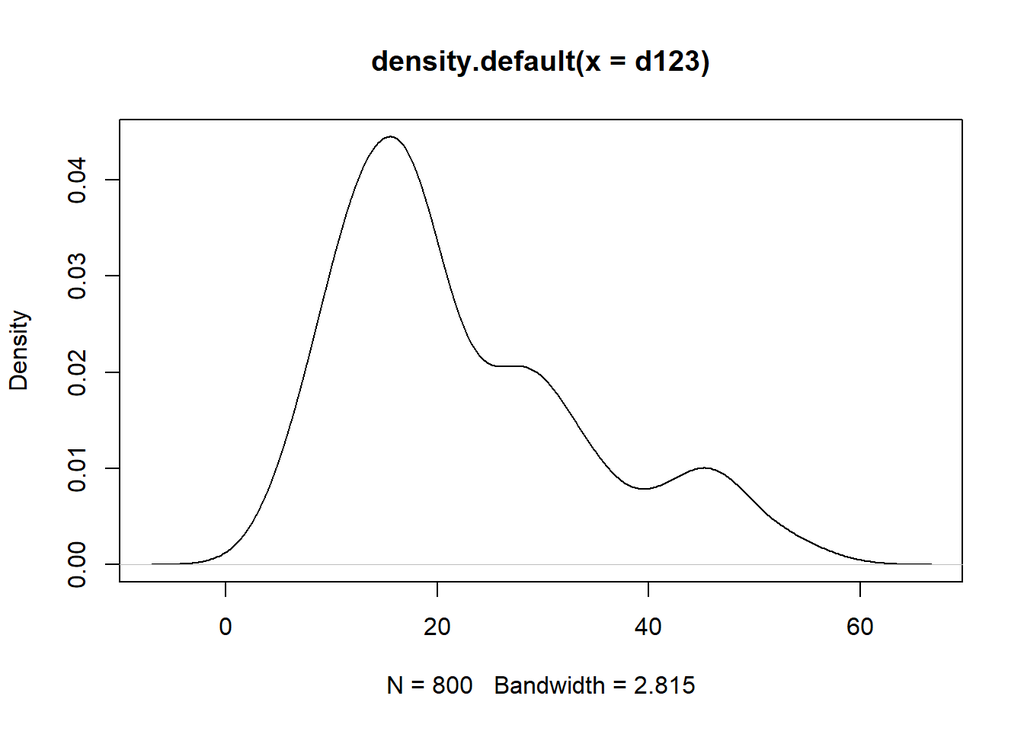

```r
set.seed(978234)
d1 <- rnorm(n=500, mean=15, sd=5)
d2 <- rnorm(n=200, mean=30, sd=5)
d3 <- rnorm(n=100, mean=45, sd=5)
d123 <- c(d1, d2, d3)

plot(density(d123))
```

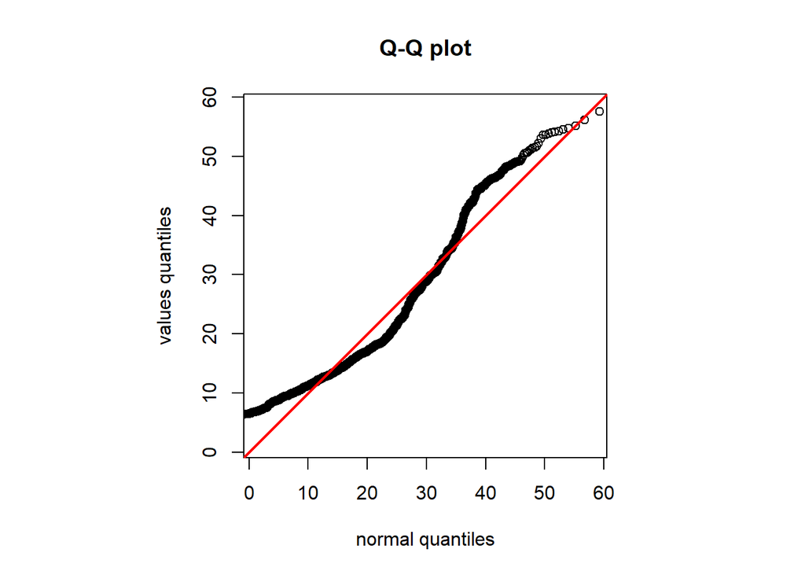

```r
par(pty="s")

norm_qq_plot(d123)
```

From the Q-Q plot we see the points stray from linearity, so d123 is not normally distributed. Check with shapiro normality test.

```r
shapiro.test(d123)
```

```
##
##  Shapiro-Wilk normality test
##
## data:  d123
## W = 0.92439, p-value < 2.2e-16
```

The result shows d123 is not normally distributed.

### c) Use your normal Q-Q plot function to check if the values from each of the CLEC and ILEC samples we compared in question 2 could be normally distributed. What’s your conclusion?

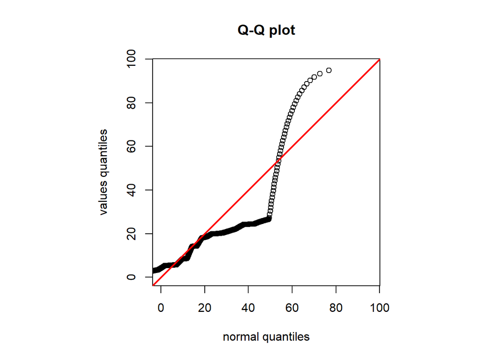

```r
par(pty="s")

norm_qq_plot(hosts$CLEC)
```

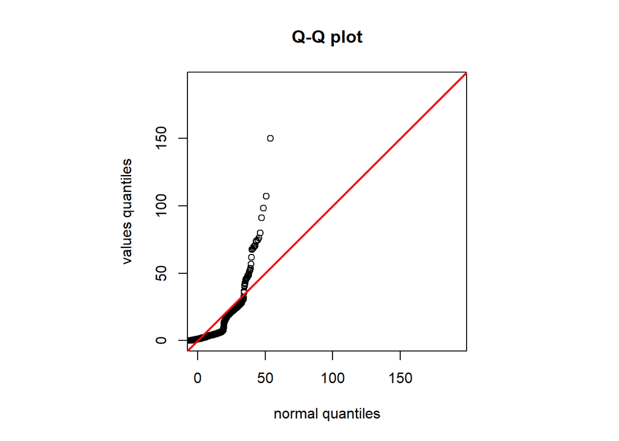

```r
norm_qq_plot(hosts$ILEC)
```

From the Q-Q plot we see the points stray from linearity, so CLEC and ILEC is not normally distributed. Check with shapiro normality test.

```r
shapiro.test(hosts$CLEC)
```

```
##
##  Shapiro-Wilk normality test
##
## data:  hosts$CLEC
## W = 0.63665, p-value = 2.339e-06
```

```r
shapiro.test(hosts$ILEC)
```

```
##
##  Shapiro-Wilk normality test
##
## data:  hosts$ILEC
## W = 0.56012, p-value < 2.2e-16
```

The result shows CLEC and ILEC is not normally distributed.